# Formative Assessment 7

DESQUITADO, Yuichi P.

2023-04-19

*Link for GitHub: https://github.com/ydesquitado/APM1110_FA7.R*

# Exercise 15.1

## 1. A machine produces memory sticks of varying lengths, distributed uniformly between 2 and 12 mm. Memory sticks longer than 10 mm do not meet the design criterion, and must be scrapped.

1. Calculate the probability that a memory stick will be scrapped.
2. Simulate 50 memory stick lengths and obtain a histogram of the simulated values. Calculate the simulated mean and variance.

### For Letter A

```r
minLength <- 2 #Shortest possible length
maxLength <- 12 #Longest possible length
totalLength <- 12 - 2 #Total length accounted for the problem
scrappedLength <- 12 - 10 #Portion of length that will be scrapped
scrappedProb <- scrappedLength/totalLength #Probability of a it being scrapped
scrappedProb #Answer for letter A
```

```
## [1] 0.2
```

### For Letter B

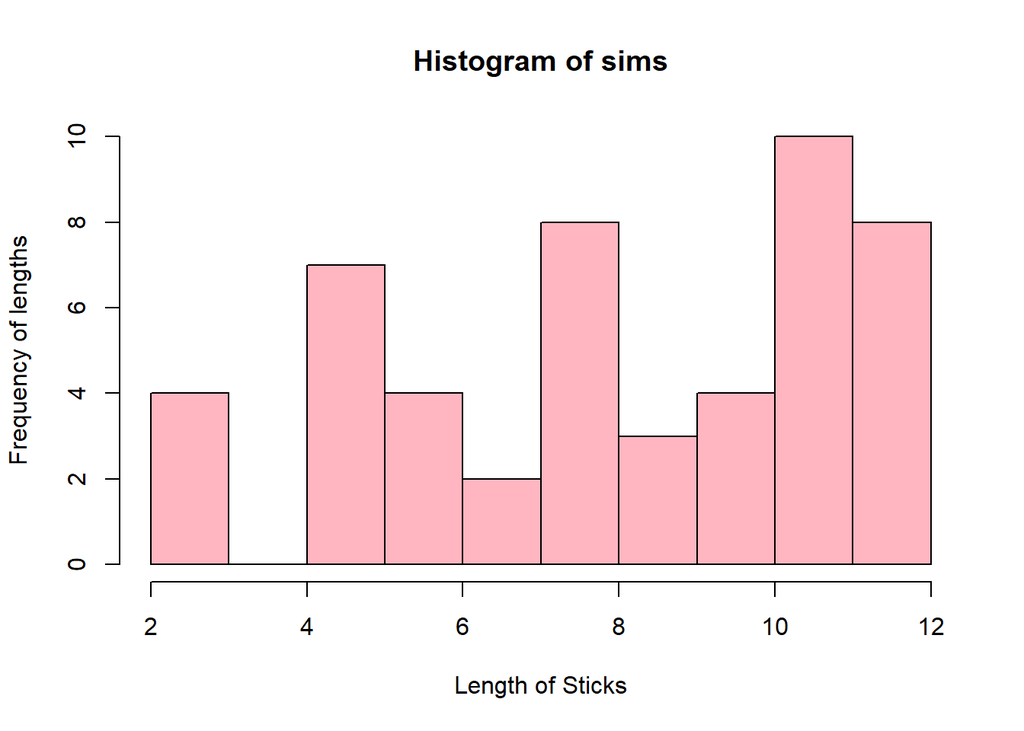

```r
runs <- 50 #Number of simulations
sims <- runif(50, 2, 12) #Simulation of production of 50 sticks ranging from 2mm to 12mm
hist(sims,
     breaks = 10,
     xlab = "Length of Sticks",
     ylab = "Frequency of lengths",
     col = "light pink")
```

```r
simsMean <- mean(sims) #Average of the sims
simsMean
```

```
## [1] 7.91731
```

```r
simsVar <- var(sims) #Variance of the sims
simsVar
```

```
## [1] 8.481399
```

## 2. Students in an electronic engineering laboratory measure current in using an ammeter. Due to several random factors, the measurement X follows the pdf

$$f(x) = 0.025x + b, 2 < x
<6$$

1. Show that, for this to be a genuine probability density, $b = 0.15$.
2. Find the probability that the measurement of the current exceeds 3 A.
3. Find $E(X)$.

### For Letter A

To first determine the genuineness of the probability density, we have to show the following:

- The area under the curve is $1$. *(This is done by getting the integral of the function from* $[-\infty, \infty]$*.)*
- The function $f(x)$ is non-negative *(It is greater than or equal to* $0$*.)*

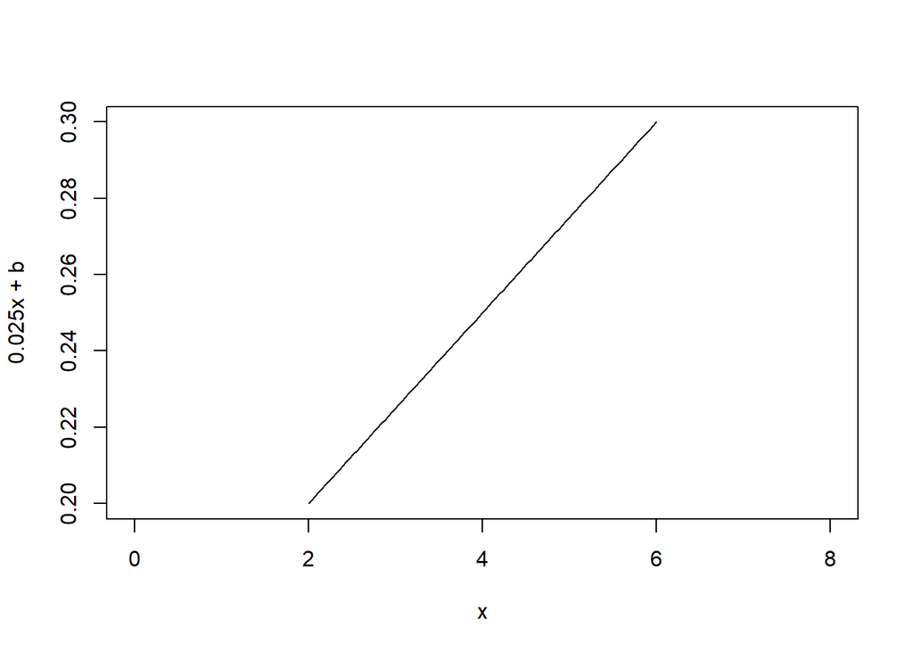

```r
b <- 0.15 #Value of b that is given

curve ((0.025 * x) + b,
       2,
       6,
       xlim = c(0, 8),
       xlab = "x",
       ylab = "0.025x + b")
```

Since $f(x)$ is bounded $[2, 6]$, we will integrate said function from $2$ to $6$.

```r
integrand <- function(x)(0.025 * x + 0.15)

integrate(integrand, 2, 6) #The bounds in question span from 2 to 6
```

```
## 1 with absolute error < 1.1e-14
```

The “with absolute error < 1.1e-14” only means that the error of computation is less than $1.1 \times 10^{-14}$, which is entirely insignificant since R has computed the integral numerically (Horgan, p. 330).

Thus, the $\int_2^6{0.025x + 0.15dx}=1$, which satisfies the first point.

For the second point, the plot has shown that the curve is illustrated above x-axis in any points within the bounds $[2,6]$, thus $f(x)$ is non-negative (or greater than or equal to 0)

### For Letter B

```r
integrate(integrand, 3, 6) #The bound asked spans from 3 to 6
```

```
## 0.7875 with absolute error < 8.7e-15
```

$$P(3 < X < 6) = \int_3^6{0.025x+0.15}dx \\ = \left[
\frac{0.025x^2}{2} + 0.15x \right]_3^6 \\ = \left(
\frac{0.025(6)^2}{2} + 0.15(6) \right) - \left( \frac{0.025(3)^2}{2} +
0.15(3) \right) \\ = \frac{27}{20} - \frac{9}{16} \\ = \frac{63}{80} =
0.7875$$
### For Letter C

To get $E(X)$, we have to get the product of $x$ and $f(x)$ first then integrate them.

```r
expectedIntegrand <- function(x)(x * (0.025 * x + 0.15))

integrate(expectedIntegrand, 2, 6)
```

```
## 4.133333 with absolute error < 4.6e-14
```

### 3. In a radio communications system, the phase difference X between the transmitter and receiver is modeled as having a uniform density in $[-\pi, \pi]$. Find $P(X \le 0)$ and $P(X \le \pi/2)$.

According to definition 15.3 from “Probability with R: An Introduction with Computer Science Application” (2020), the probability density function of a continuous uniform distribution is:

$$f(x) = \cases { \frac{1}{b - a}, & $a \le x \le b$ \cr 0, &
$otherwise$ }$$

*Note: There is no need to get the integral of pdf as the plot of* $\frac{1}{b - a}$ *is 1, given that the base is equal to* $b - a$ *while the height is* $\frac{1}{b - a}$ *, which gives us*

$$A_{pdf} = BH = (b - a) \times \frac{1}{b - a} = 1$$
*(Horgan, p. 332).*

With this definition, the pdf of the said problem is:

$$f(x) = \frac{1}{\pi - (-\pi)} \\ = \frac{1}{\pi + \pi} \\ =
\frac{1}{2\pi}$$
and

$$A_{pdf} = (\pi - (-\pi) \times \frac{1}{\pi - (-\pi)}) \\ = ((\pi + \pi)
\times \frac{1}{\pi + \pi}) \\ = 2\pi \times \frac{1}{2\pi}$$

To get the $P(X \le 0)$, we use the bounds $[-\pi, 0]$ and using `punif()`.

```r
punif(0, -pi, pi)
```

```
## [1] 0.5
```

$$P(X \le 0) = \int_{-\pi}^0{\frac{1}{2\pi}}dx \\ = \left[ \frac{x}{2\pi}
\right]_{-\pi}^0 \\ = 0 - (\frac{-\pi}{2\pi}) \\ = 0 + \frac{1}{2} \\ =
\frac{1}{2}$$

Same as the previous problem, we can get the $P(X \le \pi/2)$.

```r
punif(pi / 2, -pi, pi)
```

```
## [1] 0.75
```

$$P(X \le \pi/2) = \int_{-\pi}^{\frac{\pi}{2}}{\frac{1}{2\pi}}dx \\ =
\left[ \frac{x}{2\pi} \right]_{-\pi}^{\frac{\pi}{2}} \\ =
\frac{\frac{\pi}{2}}{2\pi} - (-\frac{\pi}{2\pi}) \\ = (\frac{\pi}{2}
\times \frac{1}{2\pi}) + \frac{1}{2} \\ = \frac{1}{4} + \frac{1}{2} \\ =
\frac{1}{4} + \frac{2}{4} \\ = \frac{3}{4} \\ = 0.75$$